# Problem Statement

## Putting the K-Medoid Clusters back into the DF

```python
#Create another copy of the scaled dataframe and name it kmedoid as this clustering was done via kmedoids
df_kmedoids = scaled_df.copy()

#Creating a label column and adding the labels from the clustering model
df_kmedoids['labels'] = model_kmedoids.labels_
df_kmedoids
```

|  | Goals_Scored | Assists | Total_Points | Minutes | Goals_Conceded | Creativity | Influence | Threat | Bonus | Clean_Sheets | labels |
| --- | --- | --- | --- | --- | --- | --- | --- | --- | --- | --- | --- |
| 0 | -0.552608 | -0.647555 | -1.122506 | -1.232383 | -1.202653 | -0.780115 | -1.039325 | -0.707638 | -0.755435 | -1.081123 | 3 |
| 1 | 3.213401 | 0.461208 | 1.375560 | 0.539871 | 0.115663 | 0.443542 | 1.150596 | 1.799393 | 2.606688 | 0.513521 | 0 |
| 2 | -0.552608 | -0.647555 | 1.414592 | 1.672585 | 1.120094 | -0.780115 | 1.523682 | -0.701346 | 1.005677 | 1.424747 | 1 |
| 3 | 0.895857 | 1.200384 | 1.082818 | 1.134662 | 0.743432 | 1.809706 | 0.741621 | 2.387618 | 0.525374 | 0.741328 | 0 |
| 4 | -0.552608 | 0.461208 | -0.439441 | -0.546229 | -0.574884 | -0.105790 | -0.459134 | -0.465428 | -0.275132 | -0.625510 | 2 |
| ... | ... | ... | ... | ... | ... | ... | ... | ... | ... | ... | ... |
| 471 | -0.552608 | -0.647555 | -1.122506 | -1.086016 | -0.763215 | -0.679404 | -0.984745 | -0.707638 | -0.755435 | -1.081123 | 3 |
| 472 | -0.552608 | -0.647555 | 1.434108 | 1.858107 | 1.998971 | -0.780115 | 1.753217 | -0.707638 | 1.165778 | 1.196940 | 1 |
| 473 | -0.552608 | -0.277967 | -0.634602 | -0.771839 | -0.700438 | -0.067576 | -0.802314 | -0.481156 | -0.755435 | -1.081123 | 3 |
| 474 | -0.262915 | -0.277967 | -0.361377 | -0.215271 | -0.386553 | -0.119723 | -0.766426 | 0.097632 | -0.275132 | 0.057909 | 2 |
| 475 | -0.262915 | -0.277967 | 0.185075 | 0.505377 | 0.617878 | -0.596606 | 0.446292 | -0.135141 | -0.115031 | 0.285715 | 2 |

476 rows × 11 columns

## K-Medoid Profiling

```python
#Creating a new DF using the mean of all columns based on the labels
profile_kmedoids = df_kmedoids.groupby('labels').mean()

#Creating a new column in the new DF called 'count', which is based on the total number of goals (the variable of interest) scored per label
profile_kmedoids['count'] = df_kmedoids.groupby('labels')['Goals_Scored'].count().values

#Highlighting the largest value of each feature to know which label is for what
profile_kmedoids.style.highlight_max()
```

| labels | Goals_Scored | Assists | Total_Points | Minutes | Goals_Conceded | Creativity | Influence | Threat | Bonus | Clean_Sheets | count |
| --- | --- | --- | --- | --- | --- | --- | --- | --- | --- | --- | --- |
| 0 | 1.623622 | 1.642087 | 1.458384 | 1.039798 | 0.922576 | 1.619838 | 1.237526 | 1.637089 | 1.577746 | 1.021918 | 82 |
| 1 | -0.242936 | -0.243982 | 0.800394 | 1.213155 | 1.097003 | -0.045353 | 1.051225 | -0.184422 | 0.363432 | 1.181229 | 87 |
| 2 | -0.164930 | -0.071433 | -0.145264 | -0.062330 | -0.011276 | -0.061769 | -0.194504 | -0.068760 | -0.290435 | -0.122996 | 136 |
| 3 | -0.523808 | -0.606490 | -0.991029 | -1.066263 | -0.991561 | -0.704564 | -0.973574 | -0.636522 | -0.710494 | -0.993198 | 171 |

```python
profile_kmedoids.style.highlight_min(color = 'limegreen')
```

| labels | Goals_Scored | Assists | Total_Points | Minutes | Goals_Conceded | Creativity | Influence | Threat | Bonus | Clean_Sheets | count |
| --- | --- | --- | --- | --- | --- | --- | --- | --- | --- | --- | --- |
| 0 | 1.623622 | 1.642087 | 1.458384 | 1.039798 | 0.922576 | 1.619838 | 1.237526 | 1.637089 | 1.577746 | 1.021918 | 82 |
| 1 | -0.242936 | -0.243982 | 0.800394 | 1.213155 | 1.097003 | -0.045353 | 1.051225 | -0.184422 | 0.363432 | 1.181229 | 87 |
| 2 | -0.164930 | -0.071433 | -0.145264 | -0.062330 | -0.011276 | -0.061769 | -0.194504 | -0.068760 | -0.290435 | -0.122996 | 136 |
| 3 | -0.523808 | -0.606490 | -0.991029 | -1.066263 | -0.991561 | -0.704564 | -0.973574 | -0.636522 | -0.710494 | -0.993198 | 171 |

- Label 0 is the players with the most value, and now got 82 of them
- Label 1 is the players who played the most
- Label 2 is ? the average players
- Label 3 is the players who are least valuable

## Presenting the data

```python
len(num_col)
```

```
10
```

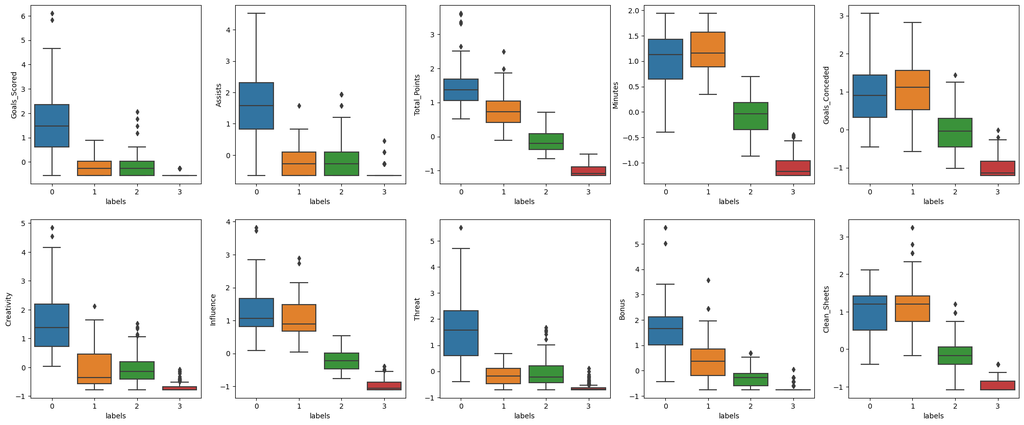

```python
#We want to plot the boxplot for all features, and we have 10 features. So we create a 2.5 subplot chart
fig,ax = plt.subplots(2,5, figsize = (25,10))

for i in range(2):
  for j in range(5):
    sns.boxplot(data = df_kmedoids,
                x = 'labels',
                y = num_col[5*i+j], #i is 0 or 1 in the range(2), and j is 0 to 4. So the total number here as it iterates is 0,1,2,3,4,5,6,7,8,9
                ax = ax[i][j]) #This is to add the plotted boxplots into each axis in the subplot
```

# Hierarchical Clustering

## Via Scikitlearn

```python
from sklearn.cluster import AgglomerativeClustering
```

Creating Model

```python
#Creating the model
model_agg = AgglomerativeClustering(n_clusters = 4, affinity = 'euclidean', linkage = 'ward')

#Fitting pca_df into the model
model_agg.fit(pca_df)

#Creating a copy of the scaled DataFrame to add the labels from the clustering
df_agg = scaled_df.copy()

#Create a new column called labels, and assign the values from the kmean models to the respective rows
df_agg['labels'] = model_agg.labels_
df_agg
```

|  | Goals_Scored | Assists | Total_Points | Minutes | Goals_Conceded | Creativity | Influence | Threat | Bonus | Clean_Sheets | labels |
| --- | --- | --- | --- | --- | --- | --- | --- | --- | --- | --- | --- |
| 0 | -0.552608 | -0.647555 | -1.122506 | -1.232383 | -1.202653 | -0.780115 | -1.039325 | -0.707638 | -0.755435 | -1.081123 | 3 |
| 1 | 3.213401 | 0.461208 | 1.375560 | 0.539871 | 0.115663 | 0.443542 | 1.150596 | 1.799393 | 2.606688 | 0.513521 | 0 |
| 2 | -0.552608 | -0.647555 | 1.414592 | 1.672585 | 1.120094 | -0.780115 | 1.523682 | -0.701346 | 1.005677 | 1.424747 | 2 |
| 3 | 0.895857 | 1.200384 | 1.082818 | 1.134662 | 0.743432 | 1.809706 | 0.741621 | 2.387618 | 0.525374 | 0.741328 | 0 |
| 4 | -0.552608 | 0.461208 | -0.439441 | -0.546229 | -0.574884 | -0.105790 | -0.459134 | -0.465428 | -0.275132 | -0.625510 | 3 |
| ... | ... | ... | ... | ... | ... | ... | ... | ... | ... | ... | ... |
| 471 | -0.552608 | -0.647555 | -1.122506 | -1.086016 | -0.763215 | -0.679404 | -0.984745 | -0.707638 | -0.755435 | -1.081123 | 3 |
| 472 | -0.552608 | -0.647555 | 1.434108 | 1.858107 | 1.998971 | -0.780115 | 1.753217 | -0.707638 | 1.165778 | 1.196940 | 2 |
| 473 | -0.552608 | -0.277967 | -0.634602 | -0.771839 | -0.700438 | -0.067576 | -0.802314 | -0.481156 | -0.755435 | -1.081123 | 3 |
| 474 | -0.262915 | -0.277967 | -0.361377 | -0.215271 | -0.386553 | -0.119723 | -0.766426 | 0.097632 | -0.275132 | 0.057909 | 1 |
| 475 | -0.262915 | -0.277967 | 0.185075 | 0.505377 | 0.617878 | -0.596606 | 0.446292 | -0.135141 | -0.115031 | 0.285715 | 1 |

476 rows × 11 columns

Cluster Profiling

```python
#Creating a new dataframe based on the labels and the mean of all the features
cluster_agg = df_agg.groupby('labels').mean()

#Create a column that tabulates the total nomber of players in each label because that is our variabale of interest
cluster_agg['count']=df_agg.groupby('labels')['Goals_Scored'].count().values

#highlight the max value of each features
cluster_agg.style.highlight_max()
```

| labels | Goals_Scored | Assists | Total_Points | Minutes | Goals_Conceded | Creativity | Influence | Threat | Bonus | Clean_Sheets | count |
| --- | --- | --- | --- | --- | --- | --- | --- | --- | --- | --- | --- |
| 0 | 1.753501 | 1.696410 | 1.504212 | 1.054119 | 0.919373 | 1.585767 | 1.285294 | 1.721706 | 1.603949 | 1.038075 | 76 |
| 1 | -0.159453 | -0.030475 | -0.091810 | 0.028768 | 0.107255 | -0.039562 | -0.129533 | -0.019176 | -0.275132 | -0.070232 | 112 |
| 2 | -0.191238 | -0.201764 | 0.779412 | 1.138218 | 1.017839 | 0.096132 | 0.979842 | -0.124115 | 0.403235 | 1.133530 | 97 |
| 3 | -0.507106 | -0.554675 | -0.940526 | -1.014357 | -0.945629 | -0.656608 | -0.933086 | -0.610800 | -0.681671 | -0.947540 | 191 |

## Via Scipy

```python
from scipy.cluster.hierarchy import linkage, cophenet, dendrogram
from scipy.spatial.distance import pdist
```

Creating the Model

```python
z = pd.DataFrame(linkage(pca_df,method= 'complete', metric = 'euclidean'))
z
```

|  | 0 | 1 | 2 | 3 |
| --- | --- | --- | --- | --- |
| 0 | 69.0 | 335.0 | 0.000000 | 2.0 |
| 1 | 396.0 | 476.0 | 0.000000 | 3.0 |
| 2 | 16.0 | 17.0 | 0.000000 | 2.0 |
| 3 | 26.0 | 478.0 | 0.000000 | 3.0 |
| 4 | 28.0 | 479.0 | 0.000000 | 4.0 |
| ... | ... | ... | ... | ... |
| 470 | 933.0 | 939.0 | 6.437897 | 8.0 |
| 471 | 944.0 | 945.0 | 7.911572 | 210.0 |
| 472 | 942.0 | 947.0 | 8.701364 | 246.0 |
| 473 | 913.0 | 948.0 | 10.186518 | 468.0 |
| 474 | 946.0 | 949.0 | 14.568409 | 476.0 |

475 rows × 4 columns

- In the first row, it is saying that row 69 and row 335 are the closest together.
- These 2 nodes form one cluster, and that cluster is now row number 476, which is the (original maximum number of rows) + 1
- In the second row, row 396 is now closest to the cluster 476, so now these 2 forms a cluster, making a cluster of 3 members
- This keeps happening, making all the closest clusters togetherm until all the points are one cluster.

## Training different types hierarchical model on one trainng data

### Cophenetic Correlation

- It is a measure of how well the dendrogram created by the hierarchical clustering represents the dissimilarities between data points
- A higher value would mean it is very good at representing the real data

```python
c, c_dist = cophenet(z, pdist(pca_df)) #This will give us the cophenetic correleation value and the dendrogramatic distance

#The cophenetic correlation can also be calculated by using this code: np.corrcoef(c_dist,pdist(pca_df))
```

### Training other models of hierarchical clustering

- We train different hierarchical clustering by changin the variables to the linkage code
- Which is the distance and method.

```python
#List down the different distance options
distance_= ['euclidean',
            'chebyshev',
            'mahalanobis']

#List down the different method options
linkage_ = ['single',
            'complete',
            'average'] #Ward is not used here because it only works for euclidean distances

#Finding the option combination that gives the maximum Cophenetic Correlation

#Define a smallest possib le number first
c_max = -float('inf')

for i in distance_:
  for j in linkage_:

    z = pd.DataFrame(linkage(pca_df, metric = i, method= j))
    c, c_dist = cophenet(z, pdist(pca_df))
    print(i,j,c)

    if c > c_max:
      c_max = c #Replace the c_max value if the current cophenetic correlation is larger.
      index_max = (i,j) #note down the method and distance options for this cophenetic correlation

print('Best combination is: ', index_max)
print('Highest cophenetic correlation is: ', c_max)
```

```
euclidean single 0.8430175514228706
euclidean complete 0.7412041292261757
euclidean average 0.8476499945585417
chebyshev single 0.8381223141111799
chebyshev complete 0.8028394390632132
chebyshev average 0.8167064931302256
mahalanobis single 0.8065008904132246
mahalanobis complete 0.6583135946489014
mahalanobis average 0.7747800632434059
Best combination is:  ('euclidean', 'average')
Highest cophenetic correlation is:  0.8476499945585417
```

Seeing if ward method does any better

```python
#Now trying out to see if ward is any better
distance_= ['euclidean']

#List down the different method options
linkage_ = ['single',
            'complete',
            'average',
            'ward']

for i in distance_:
  for j in linkage_:

    z = pd.DataFrame(linkage(pca_df, metric = i, method= j))
    c, c_dist = cophenet(z, pdist(pca_df))
    print(i,j,c)

    if c > c_max:
      c_max = c #Replace the c_max value if the current cophenetic correlation is larger.
      index_max = (i,j) #note down the method and distance options for this cophenetic correlation

print('Best combination is: ', index_max)
print('Highest cophenetic correlation is: ', c_max)
```

```
euclidean single 0.8430175514228706
euclidean complete 0.7412041292261757
euclidean average 0.8476499945585417
euclidean ward 0.577773844586155
Best combination is:  ('euclidean', 'average')
Highest cophenetic correlation is:  0.8476499945585417
```

As can be seen, the euclidean and average combination is still the best hierarchical clustering method

### Dendrogram

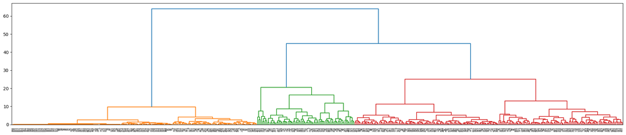

```python
plt.figure(figsize = (25,5))
dendrogram(z);
```

- The lower we go down the dendrogram, the more clusters we will have.

# Gaussian Mixture Modelling

```python
from sklearn.mixture import GaussianMixture
```

Create the model

```python
model_gmm = GaussianMixture(n_components = 4, random_state = 0)
model_gmm.fit(pca_df)
model_gmm
```

```
GaussianMixture(n_components=4, random_state=0)
```

Adding labels from model into the dataframe

```python
df_gmm = scaled_df.copy()
df_gmm['label'] = model_gmm.predict(pca_df) #Cannot use .labels_ like before
df_gmm
```

|  | Goals_Scored | Assists | Total_Points | Minutes | Goals_Conceded | Creativity | Influence | Threat | Bonus | Clean_Sheets | label |
| --- | --- | --- | --- | --- | --- | --- | --- | --- | --- | --- | --- |
| 0 | -0.552608 | -0.647555 | -1.122506 | -1.232383 | -1.202653 | -0.780115 | -1.039325 | -0.707638 | -0.755435 | -1.081123 | 2 |
| 1 | 3.213401 | 0.461208 | 1.375560 | 0.539871 | 0.115663 | 0.443542 | 1.150596 | 1.799393 | 2.606688 | 0.513521 | 1 |
| 2 | -0.552608 | -0.647555 | 1.414592 | 1.672585 | 1.120094 | -0.780115 | 1.523682 | -0.701346 | 1.005677 | 1.424747 | 3 |
| 3 | 0.895857 | 1.200384 | 1.082818 | 1.134662 | 0.743432 | 1.809706 | 0.741621 | 2.387618 | 0.525374 | 0.741328 | 1 |
| 4 | -0.552608 | 0.461208 | -0.439441 | -0.546229 | -0.574884 | -0.105790 | -0.459134 | -0.465428 | -0.275132 | -0.625510 | 0 |
| ... | ... | ... | ... | ... | ... | ... | ... | ... | ... | ... | ... |
| 471 | -0.552608 | -0.647555 | -1.122506 | -1.086016 | -0.763215 | -0.679404 | -0.984745 | -0.707638 | -0.755435 | -1.081123 | 2 |
| 472 | -0.552608 | -0.647555 | 1.434108 | 1.858107 | 1.998971 | -0.780115 | 1.753217 | -0.707638 | 1.165778 | 1.196940 | 3 |
| 473 | -0.552608 | -0.277967 | -0.634602 | -0.771839 | -0.700438 | -0.067576 | -0.802314 | -0.481156 | -0.755435 | -1.081123 | 0 |
| 474 | -0.262915 | -0.277967 | -0.361377 | -0.215271 | -0.386553 | -0.119723 | -0.766426 | 0.097632 | -0.275132 | 0.057909 | 0 |
| 475 | -0.262915 | -0.277967 | 0.185075 | 0.505377 | 0.617878 | -0.596606 | 0.446292 | -0.135141 | -0.115031 | 0.285715 | 3 |

476 rows × 11 columns

Cluster Profiling

```python
profile_gmm = df_gmm.groupby('label').mean()
profile_gmm['count'] = df_gmm.groupby('label')['Assists'].count().values
profile_gmm.style.highlight_max()
profile_gmm.style.highlight_min(color = 'limegreen')
```

| label | Goals_Scored | Assists | Total_Points | Minutes | Goals_Conceded | Creativity | Influence | Threat | Bonus | Clean_Sheets | count |
| --- | --- | --- | --- | --- | --- | --- | --- | --- | --- | --- | --- |
| 0 | -0.368462 | -0.326673 | -0.477868 | -0.398958 | -0.312097 | -0.354761 | -0.482892 | -0.359063 | -0.497287 | -0.489533 | 129 |
| 1 | 1.345571 | 1.344700 | 1.099917 | 0.715893 | 0.656740 | 1.217027 | 0.847982 | 1.442265 | 1.150530 | 0.669731 | 105 |
| 2 | -0.552608 | -0.647555 | -1.072786 | -1.146206 | -1.073612 | -0.745919 | -1.042541 | -0.689563 | -0.755435 | -1.039539 | 126 |
| 3 | -0.207973 | -0.150523 | 0.701075 | 1.040679 | 0.918775 | 0.103123 | 0.901854 | -0.157187 | 0.332148 | 1.067326 | 116 |

# Density-based Clustering Algorithms (DBSCAN)

```python
from sklearn.cluster import DBSCAN
```

## Model Creation

```python
model_dbs = DBSCAN(eps = 3, min_samples = 15)
model_dbs.fit(pca_df)
```

```
DBSCAN(eps=3, min_samples=15)
```

DataFrame Labelling

```python
df_dbs = scaled_df.copy()
df_dbs['label'] = model_dbs.labels_ #Cannot use .predict like before
df_dbs
```

|  | Goals_Scored | Assists | Total_Points | Minutes | Goals_Conceded | Creativity | Influence | Threat | Bonus | Clean_Sheets | label |
| --- | --- | --- | --- | --- | --- | --- | --- | --- | --- | --- | --- |
| 0 | -0.552608 | -0.647555 | -1.122506 | -1.232383 | -1.202653 | -0.780115 | -1.039325 | -0.707638 | -0.755435 | -1.081123 | 0 |
| 1 | 3.213401 | 0.461208 | 1.375560 | 0.539871 | 0.115663 | 0.443542 | 1.150596 | 1.799393 | 2.606688 | 0.513521 | 0 |
| 2 | -0.552608 | -0.647555 | 1.414592 | 1.672585 | 1.120094 | -0.780115 | 1.523682 | -0.701346 | 1.005677 | 1.424747 | 0 |
| 3 | 0.895857 | 1.200384 | 1.082818 | 1.134662 | 0.743432 | 1.809706 | 0.741621 | 2.387618 | 0.525374 | 0.741328 | 0 |
| 4 | -0.552608 | 0.461208 | -0.439441 | -0.546229 | -0.574884 | -0.105790 | -0.459134 | -0.465428 | -0.275132 | -0.625510 | 0 |
| ... | ... | ... | ... | ... | ... | ... | ... | ... | ... | ... | ... |
| 471 | -0.552608 | -0.647555 | -1.122506 | -1.086016 | -0.763215 | -0.679404 | -0.984745 | -0.707638 | -0.755435 | -1.081123 | 0 |
| 472 | -0.552608 | -0.647555 | 1.434108 | 1.858107 | 1.998971 | -0.780115 | 1.753217 | -0.707638 | 1.165778 | 1.196940 | 0 |
| 473 | -0.552608 | -0.277967 | -0.634602 | -0.771839 | -0.700438 | -0.067576 | -0.802314 | -0.481156 | -0.755435 | -1.081123 | 0 |
| 474 | -0.262915 | -0.277967 | -0.361377 | -0.215271 | -0.386553 | -0.119723 | -0.766426 | 0.097632 | -0.275132 | 0.057909 | 0 |
| 475 | -0.262915 | -0.277967 | 0.185075 | 0.505377 | 0.617878 | -0.596606 | 0.446292 | -0.135141 | -0.115031 | 0.285715 | 0 |

476 rows × 11 columns

```python
df_dbs['label'].unique()
```

```
array([ 0, -1])
```

- As can be seen, there are only 2 kinds of cluster from the DBS Scan.
- the -1 labels are outliers

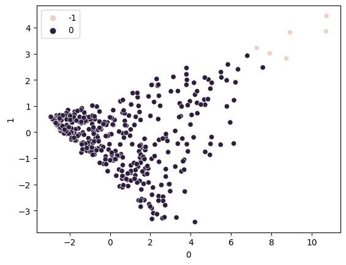

```python
sns.scatterplot(data = pca_df,
                x = 0, #Using the first 2 PCA components because they are the most relevant ones
                y = 1,
                hue = model_dbs.labels_); #Separating them based on the difference in labels column
```

## DBSCAN Model Tuning

We change the variable and find out the silhouette score. Silhouette Score finds out how good the clustering is by looking at the within and inter-group distances

```python
#Write out the list of epsilon
eps_ = [0.5,1,2,3,4,5]

#write out the list of min_samples
min_s = [3,5,10,15,20]

#Define a max score value to find the max score
max_score = -float('inf')

for i in eps_:
  for j in min_s:

    model_dbs = DBSCAN(eps = i, min_samples = j).fit(pca_df)
    print(np.unique(model_dbs.labels_)) # To show us how many clusters are there

    #Calculating the silhouette score if there are clustering
    if len(np.unique(model_dbs.labels_)) > 1:

      score = silhouette_score(pca_df,model_dbs.labels_)
      print(score)

      #Finding hte max score
      if score > max_score:
        max_score = score
        idx_max = [i,j]
print(f'Best combination is {idx_max}')
```

```
[-1  0  1  2  3  4]
0.03706830503123459
[-1  0]
0.3505148065884733
[-1  0]
0.33561855538605684
[-1  0]
0.31654480791443135
[-1  0]
0.3127307717825767
[-1  0  1]
0.34619967131360324
[-1  0  1  2]
0.238447062236738
[-1  0]
0.46081684597157613
[-1  0]
0.4637989004347497
[-1  0]
0.46006267812486407
[-1  0]
0.5719599277943452
[-1  0]
0.5258910630765612
[-1  0]
0.5240489367504121
[-1  0]
0.5122411697457523
[-1  0  1]
0.36478187504220944
[-1  0]
0.6376550045054882
[-1  0]
0.6242051897980097
[-1  0]
0.6188492415713208
[-1  0]
0.6188492415713208
[-1  0]
0.6188492415713208
[0]
[0]
[0]
[-1  0]
0.6626466090568284
[-1  0]
0.6626466090568284
[0]
[0]
[0]
[0]
[0]
Best combination is [4, 15]
```

## Outlier Profiling

```python
#Create the model using the best variables first
model_dbs = DBSCAN(eps = 4, min_samples = 15).fit(pca_df)

#Labelling the dataframe
df_dbs = scaled_df.copy()
df_dbs['label'] = model_dbs.labels_ #Cannot use .predict like before
df_dbs
```

|  | Goals_Scored | Assists | Total_Points | Minutes | Goals_Conceded | Creativity | Influence | Threat | Bonus | Clean_Sheets | label |
| --- | --- | --- | --- | --- | --- | --- | --- | --- | --- | --- | --- |
| 0 | -0.552608 | -0.647555 | -1.122506 | -1.232383 | -1.202653 | -0.780115 | -1.039325 | -0.707638 | -0.755435 | -1.081123 | 0 |
| 1 | 3.213401 | 0.461208 | 1.375560 | 0.539871 | 0.115663 | 0.443542 | 1.150596 | 1.799393 | 2.606688 | 0.513521 | 0 |
| 2 | -0.552608 | -0.647555 | 1.414592 | 1.672585 | 1.120094 | -0.780115 | 1.523682 | -0.701346 | 1.005677 | 1.424747 | 0 |
| 3 | 0.895857 | 1.200384 | 1.082818 | 1.134662 | 0.743432 | 1.809706 | 0.741621 | 2.387618 | 0.525374 | 0.741328 | 0 |
| 4 | -0.552608 | 0.461208 | -0.439441 | -0.546229 | -0.574884 | -0.105790 | -0.459134 | -0.465428 | -0.275132 | -0.625510 | 0 |
| ... | ... | ... | ... | ... | ... | ... | ... | ... | ... | ... | ... |
| 471 | -0.552608 | -0.647555 | -1.122506 | -1.086016 | -0.763215 | -0.679404 | -0.984745 | -0.707638 | -0.755435 | -1.081123 | 0 |
| 472 | -0.552608 | -0.647555 | 1.434108 | 1.858107 | 1.998971 | -0.780115 | 1.753217 | -0.707638 | 1.165778 | 1.196940 | 0 |
| 473 | -0.552608 | -0.277967 | -0.634602 | -0.771839 | -0.700438 | -0.067576 | -0.802314 | -0.481156 | -0.755435 | -1.081123 | 0 |
| 474 | -0.262915 | -0.277967 | -0.361377 | -0.215271 | -0.386553 | -0.119723 | -0.766426 | 0.097632 | -0.275132 | 0.057909 | 0 |
| 475 | -0.262915 | -0.277967 | 0.185075 | 0.505377 | 0.617878 | -0.596606 | 0.446292 | -0.135141 | -0.115031 | 0.285715 | 0 |

476 rows × 11 columns

```python
#Finding out the rows that have been labeled as outliers
df_dbs[df_dbs['label'] == -1]
```

|  | Goals_Scored | Assists | Total_Points | Minutes | Goals_Conceded | Creativity | Influence | Threat | Bonus | Clean_Sheets | label |
| --- | --- | --- | --- | --- | --- | --- | --- | --- | --- | --- | --- |
| 315 | 4.661866 | 4.526676 | 3.619915 | 1.644616 | 1.057317 | 4.852129 | 3.730800 | 3.233780 | 5.008204 | 1.880359 | -1 |
| 403 | 6.110330 | 4.526676 | 3.580883 | 1.627835 | 1.245648 | 1.843542 | 3.826501 | 4.278114 | 5.648609 | 1.652553 | -1 |

```python
df.iloc[[315,403],:]
```

|  | Player_Name | Club | Position | Goals_Scored | Assists | Total_Points | Minutes | Goals_Conceded | Creativity | Influence | Threat | Bonus | Clean_Sheets |
| --- | --- | --- | --- | --- | --- | --- | --- | --- | --- | --- | --- | --- | --- |
| 315 | Bruno Fernandes | Manchester United | Midfielder | 18 | 14 | 244 | 3101 | 36 | 1414.9 | 1292.6 | 1253 | 36 | 13 |
| 403 | Harry Kane | Tottenham Hotspurs | Forward | 23 | 14 | 242 | 3083 | 39 | 659.1 | 1318.2 | 1585 | 40 | 12 |

These 2 players are the outliers from the rest of the players, either they are really good, or really bad

# Model Comparison

We can compare the performance of the different clustering techniques using the silhouette score

```python
models_ = [model_kmeans,model_kmedoids, model_agg, model_gmm, model_dbs]

for i in models_:
  try:
    score = silhouette_score(pca_df,i.predict(pca_df))
  except:
    score = silhouette_score(pca_df,i.labels_)
  print(f'The Silhouette Score for {i} is {score}.')
```

```
The Silhouette Score for KMeans(n_clusters=4, random_state=0) is 0.40409310663893694.
The Silhouette Score for KMedoids(n_clusters=4, random_state=0) is 0.3938224989846948.
The Silhouette Score for AgglomerativeClustering(affinity='euclidean', n_clusters=4) is 0.38497099800605145.
The Silhouette Score for GaussianMixture(n_components=4, random_state=0) is 0.2849464415241945.
The Silhouette Score for DBSCAN(eps=4, min_samples=15) is 0.6626466090568284.
```